# Session 2

R Introduction Workshop

April 29, 2019

# Subsetting

**Subset notation:**  
1. Name of the R object  
2. Square brackets `[ ]`  
3. The index of the element

- The index tells R which elements from that object to include.
- Every dimension of the R object needs an index! This means a vector, which is a one dimensional R object would require only one index. A two dimensional R object such as a data frame or a matrix would require an index for rows and another for the columns.
- For two dimensional objects, first index (the on the left) in the brackets specifies the rows and the second specifies the columns.

**There are four main ways to subset R objects**  
1. Integers  
2. Blank spaces  
3. Names  
4. Logical vectors (TRUE and FALSE)

## 1. Integers

Positive integers behave just like *ij* notation in linear algebra.

Lets work with an example data frame `df` inspired from the Beatles.

```r
df <- data.frame(name=c("John","Paul","George","Ringo"),
                 birth=c(1940, 1942, 1943, 1940),
                 insturment=c("guitar", "bass","guitar","drums") )
df
```

```
##     name birth insturment
## 1   John  1940     guitar
## 2   Paul  1942       bass
## 3 George  1943     guitar
## 4  Ringo  1940      drums
```

The following gives the element in 2nd row and 3rd column.

```r
df[2,3]
```

```
## [1] bass
## Levels: bass drums guitar
```

### Multiple integers to subset

By giving vectors as indices, we can also get multiple rows and columns, giving multiple elements.

The following gives the elements that are in 2nd and 4th rows and the 3rd column.

```r
df[c(2,4),3]
```

```
## [1] bass  drums
## Levels: bass drums guitar
```

The following gives the elements that are in 2nd & 4th rows and 2nd & 3rd columns.

```r
df[c(2,4),c(2,3)]
```

```
##   birth insturment
## 2  1942       bass
## 4  1940      drums
```

When selecting a series of rows and columns in a sequential manner, `:` becomes very handy.  
(Remember: `start:end` gives us a sequence of integers. For example `1:10` gives a vector of integers from 1 to 10.)

Select rows from 1 to 3 and columns from 1 to 2.

```r
df[1:3, 1:2]
```

```
##     name birth
## 1   John  1940
## 2   Paul  1942
## 3 George  1943
```

### Repeating integers

Also repeating input repeats output.

```r
df[c(1,1,1,2,2), 1:3]
```

```
##     name birth insturment
## 1   John  1940     guitar
## 1.1 John  1940     guitar
## 1.2 John  1940     guitar
## 2   Paul  1942       bass
## 2.1 Paul  1942       bass
```

Do you see those unusual row numbers? It is because rownames or numbers has to be unique. When rows are repeated, R introduces secondary numbers to deal with this issue in its own way.

### Integer `0`

As an index, **zero will return nothing** from a dimension. This creates an empty object.

```r
df[1:2,0]
```

```
## data frame with 0 columns and 2 rows
```

### Negative integers

Negative integers return **everything but** the elements at the specified locations.  
You cannot use both negative and positive integers in the same dimension

Exclude rows 2 to 4 and select columns 2 to 3.

```r
df[-c(2:4), 2:3]
```

```
##   birth insturment
## 1  1940     guitar
```

Exclude rows 2 to 4 and select columns 2 to 3.

```r
df[-c(2:4), 2:3]
```

```
##   birth insturment
## 1  1940     guitar
```

## 2. Blank Spaces

Blank spaces return **everything** (i.e., no subsetting occurs on that dimension)

```r
vec <- c(6,1,3,6,10,5)
vec[]
```

```
## [1]  6  1  3  6 10  5
```

Return every element on row 1

```r
df[1,]
```

```
##   name birth insturment
## 1 John  1940     guitar
```

Return every element on column 2

```r
df[,2]
```

```
## [1] 1940 1942 1943 1940
```

## 3. Names

If your object has names, you can ask for elements or columns back by name. (We talked about this in the first session)

```r
names(vec) <- c("a","b","c","d","e","f")
vec
```

```
##  a  b  c  d  e  f
##  6  1  3  6 10  5
```

Now I can call elements in `vec` by their names

```r
vec[c("a","b","d")]
```

```
## a b d
## 6 1 6
```

Same applies to columns and column names

```r
df[ ,"birth"]
```

```
## [1] 1940 1942 1943 1940
```

```r
df[ ,c("name","birth")]
```

```
##     name birth
## 1   John  1940
## 2   Paul  1942
## 3 George  1943
## 4  Ringo  1940
```

## 4. Logical

You can subset with a logical vector of the **same length as the dimension** you are subsetting. Each element that corresponds to a TRUE will be returned.

The following will return 2nd, 4th and 5th elements in `vec`

```r
vec[c(FALSE,TRUE,FALSE,TRUE,TRUE,FALSE)]
```

```
##  b  d  e
##  1  6 10
```

The following will return **2nd, 3rd rows** in `df`

```r
df[c(FALSE,TRUE,TRUE,FALSE), ]
```

```
##     name birth insturment
## 2   Paul  1942       bass
## 3 George  1943     guitar
```

## Subsetting Lists

Subsetting lists can get tricky, since a list can contain objects that has one or more dimensions.

```r
lst <- list(c(1,2), TRUE, c("a", "b", "c"))
lst
```

```
## [[1]]
## [1] 1 2
##
## [[2]]
## [1] TRUE
##
## [[3]]
## [1] "a" "b" "c"
```

What is the difference?

```r
lst[c(1,2)]  # outputs a list with 2 objects
lst[1]       # outputs a list with 1 object
lst[[1]]     # outputs a vector
```

```r
lst[c(1,2)]  # outputs a list with 2 objects
```

```
## [[1]]
## [1] 1 2
##
## [[2]]
## [1] TRUE
```

```r
lst[1]       # outputs a list with 1 object
```

```
## [[1]]
## [1] 1 2
```

```r
lst[[1]]     # outputs a vector
```

```
## [1] 1 2
```

Think this way: If list `x` is a train carrying objects, then `x[[5]]` is the *object* in car 5, whereas x[5] is a train with car 5 only.

### Easiest way to subset data frames and lists: `$` sign

The most common syntax for subsetting lists and data frames:

When we have a names list such as

```r
names(lst) <- c("alpha", "beta", "gamma")
lst
```

```
## $alpha
## [1] 1 2
##
## $beta
## [1] TRUE
##
## $gamma
## [1] "a" "b" "c"
```

then we can subset objects with `$`

```r
lst$alpha
```

```
## [1] 1 2
```

```r
lst$beta
```

```
## [1] TRUE
```

```r
lst$gamma
```

```
## [1] "a" "b" "c"
```

It also works to subset columns of a data frame

```r
df$birth
```

```
## [1] 1940 1942 1943 1940
```

A nice shortcut: if you can’t remember all the names in your list or columns in your data frame, you can simply tap `Tab` button and you can see the list.

# R Packages

- A collection of code and functions written for the R language.
- Usually focuses on a specific task or problem.
- Most of the useful R applications appear in packages.
- You need to install a package only **one time** using `install.packages()` function.  
  For example simply type `install.packages("ggplot2")` to the R console to install the `ggplot2` package.
- **You cannot use a function in a package until you load the package!**
- If you want to use the functions or data that comes with a certain package, you need to load that package **every time** you start an R session. To load a package you can use the `library()` package.  
  For example simply type `library(ggplot2)` to the R console to load the `ggplot2` package.
- It is wise to add the packages you will use at the beginning of you R script – so if you ever share that script with someone else or if you ever forget that certain functions you used in the script belong to a certain package, you can remember which packages you used by looking at the beginning of your code.

## Your turn

Install these packages : `ggplot2`, `maps`, `RColorBrewer`

```r
# install.packages(c("ggplot2", "maps", "RColorBrewer"))
library("ggplot2")
library("maps")
library("RColorBrewer")
```

# Diamonds data

```r
# assign diamonds
diamonds <- data.frame(diamonds)
```

Look at your environent, you can see the `diamonds` data is huge.

- Use subsetting to look at just the first six rows of diamonds
- Challenge: use subsetting to look at just the last six rows

Subsetting first 6 rows is easy

```r
# first 6 rows
diamonds[1:6,]
```

```
##   carat       cut color clarity depth table price    x    y    z
## 1  0.23     Ideal     E     SI2  61.5    55   326 3.95 3.98 2.43
## 2  0.21   Premium     E     SI1  59.8    61   326 3.89 3.84 2.31
## 3  0.23      Good     E     VS1  56.9    65   327 4.05 4.07 2.31
## 4  0.29   Premium     I     VS2  62.4    58   334 4.20 4.23 2.63
## 5  0.31      Good     J     SI2  63.3    58   335 4.34 4.35 2.75
## 6  0.24 Very Good     J    VVS2  62.8    57   336 3.94 3.96 2.48
```

```r
# last 6 rows
dim(diamonds)
```

```
## [1] 53940    10
```

```r
ncol(diamonds) # number of columns
```

```
## [1] 10
```

```r
#one way
nrow(diamonds) # number of rows
```

```
## [1] 53940
```

```r
nrow(diamonds) - 6
```

```
## [1] 53934
```

```r
diamonds[53934:53940,]
```

```
##       carat       cut color clarity depth table price    x    y    z
## 53934  0.70 Very Good     E     VS2  61.2    59  2757 5.69 5.72 3.49
## 53935  0.72   Premium     D     SI1  62.7    59  2757 5.69 5.73 3.58
## 53936  0.72     Ideal     D     SI1  60.8    57  2757 5.75 5.76 3.50
## 53937  0.72      Good     D     SI1  63.1    55  2757 5.69 5.75 3.61
## 53938  0.70 Very Good     D     SI1  62.8    60  2757 5.66 5.68 3.56
## 53939  0.86   Premium     H     SI2  61.0    58  2757 6.15 6.12 3.74
## 53940  0.75     Ideal     D     SI2  62.2    55  2757 5.83 5.87 3.64
```

```r
# another way
diamonds[(nrow(diamonds)-6):nrow(diamonds),]
```

```
##       carat       cut color clarity depth table price    x    y    z
## 53934  0.70 Very Good     E     VS2  61.2    59  2757 5.69 5.72 3.49
## 53935  0.72   Premium     D     SI1  62.7    59  2757 5.69 5.73 3.58
## 53936  0.72     Ideal     D     SI1  60.8    57  2757 5.75 5.76 3.50
## 53937  0.72      Good     D     SI1  63.1    55  2757 5.69 5.75 3.61
## 53938  0.70 Very Good     D     SI1  62.8    60  2757 5.66 5.68 3.56
## 53939  0.86   Premium     H     SI2  61.0    58  2757 6.15 6.12 3.74
## 53940  0.75     Ideal     D     SI2  62.2    55  2757 5.83 5.87 3.64
```

```r
head(diamonds)
```

```
##   carat       cut color clarity depth table price    x    y    z
## 1  0.23     Ideal     E     SI2  61.5    55   326 3.95 3.98 2.43
## 2  0.21   Premium     E     SI1  59.8    61   326 3.89 3.84 2.31
## 3  0.23      Good     E     VS1  56.9    65   327 4.05 4.07 2.31
## 4  0.29   Premium     I     VS2  62.4    58   334 4.20 4.23 2.63
## 5  0.31      Good     J     SI2  63.3    58   335 4.34 4.35 2.75
## 6  0.24 Very Good     J    VVS2  62.8    57   336 3.94 3.96 2.48
```

```r
tail(diamonds)
```

```
##       carat       cut color clarity depth table price    x    y    z
## 53935  0.72   Premium     D     SI1  62.7    59  2757 5.69 5.73 3.58
## 53936  0.72     Ideal     D     SI1  60.8    57  2757 5.75 5.76 3.50
## 53937  0.72      Good     D     SI1  63.1    55  2757 5.69 5.75 3.61
## 53938  0.70 Very Good     D     SI1  62.8    60  2757 5.66 5.68 3.56
## 53939  0.86   Premium     H     SI2  61.0    58  2757 6.15 6.12 3.74
## 53940  0.75     Ideal     D     SI2  62.2    55  2757 5.83 5.87 3.64
```

**View** The `View()` function can also help you examine a data set, it opens a spreadsheet like data viewer.

```r
View(diamonds) # notice: Capital V
```

**Help pages** You can open the help page for any R object (including functions) by typing `?` followed by the object’s name

```r
?diamonds
```

# Logical tests

## Logical comparisons

What will these return?

```r
1< 3
```

```
## [1] TRUE
```

```r
1> 3
```

```
## [1] FALSE
```

```r
c(1, 2, 3, 4, 5) > 3
```

```
## [1] FALSE FALSE FALSE  TRUE  TRUE
```

Logical Operators

| Operator | Tests |
| --- | --- |
| x > y | is x greater than y? |
| x >= y | is x greater than or equal to y? |
| x < y | is x less than y? |
| x <= y | is x less than or equal to y? |
| x == y | is x equal to y? |
| x != y | is x not equal to y? |
| x %in% c(y,z) | is x in the set c(y,z)? |

## `%in%`

What does this do?

```r
1 %in% c(1, 2, 3, 4)
1 %in% c(2, 3, 4)
c(3,4,5,6) %in% c(2, 3, 4)
```

`%in%` tests whether the object on the left is a member of the group on the right.

```r
1 %in% c(1, 2, 3, 4)
```

```
## [1] TRUE
```

```r
1 %in% c(2, 3, 4)
```

```
## [1] FALSE
```

```r
c(3,4,5,6) %in% c(2, 3, 4)
```

```
## [1]  TRUE  TRUE FALSE FALSE
```

## Boolean operators

You can combine logical tests with `&`, `|`, `xor`, `!`, `any`, and `all`

Boolean Operators

| Operator | Tests |
| --- | --- |
| a & b | both a and b are TRUE |
| a \| b | at least one of a and b is TRUE (or) |
| xor(a,b) | a is TRUE or b is TRUE, but not both |
| !(a) | not a (TRUE goes to FALSE, FALSE goes to TRUE) |
| any(a,b,c) | at least one of a, b, or c is TRUE |
| all(a,b,c) | each of a, b, and c is TRUE |

### Your turn

```r
w <- c(-1, 0, 1)
x <- c(5, 15)
y <- "February"
z <- c("Monday", "Tuesday", "Friday")
```

**Questions**

- Is w positive?
- Is x greater than 10 and less than 20? Is object y the word February?
- Is every value in z a day of the week?

**Common mistakes**

```r
x > 10 & < 20
y = "February"
all(z == "Monday" | "Tuesday" | "Wednesday"...)
```

# Logical subsetting

Combining logical tests with subsetting is a very powerful technique! It is very commonly used to subset, clean and manipulate data.

```r
x_zeroes <- diamonds$x == 0
head(x_zeroes)
```

```
## [1] FALSE FALSE FALSE FALSE FALSE FALSE
```

What will this return?

```r
diamonds[x_zeroes, ]
```

```
##       carat       cut color clarity depth table price x    y z
## 11183  1.07     Ideal     F     SI2  61.6    56  4954 0 6.62 0
## 11964  1.00 Very Good     H     VS2  63.3    53  5139 0 0.00 0
## 15952  1.14      Fair     G     VS1  57.5    67  6381 0 0.00 0
## 24521  1.56     Ideal     G     VS2  62.2    54 12800 0 0.00 0
## 26244  1.20   Premium     D    VVS1  62.1    59 15686 0 0.00 0
## 27430  2.25   Premium     H     SI2  62.8    59 18034 0 0.00 0
## 49557  0.71      Good     F     SI2  64.1    60  2130 0 0.00 0
## 49558  0.71      Good     F     SI2  64.1    60  2130 0 0.00 0
```

## Saving results

This will print to screen

```r
diamonds[diamonds$x > 10, ]
```

```
##       carat       cut color clarity depth table price     x     y    z
## 25999  4.01   Premium     I      I1  61.0    61 15223 10.14 10.10 6.17
## 26000  4.01   Premium     J      I1  62.5    62 15223 10.02  9.94 6.24
## 26445  4.00 Very Good     I      I1  63.3    58 15984 10.01  9.94 6.31
## 27416  5.01      Fair     J      I1  65.5    59 18018 10.74 10.54 6.98
## 27631  4.50      Fair     J      I1  65.8    58 18531 10.23 10.16 6.72
```

This will save to new data frame

```r
big <- diamonds[diamonds$x > 10, ]
```

This will overwrite the existing data frame. **Dangerous! Don’t do it if you don’t have to! Think twice!**

```r
diamonds <- diamonds[diamonds$x < 10,]
```

# Missing values

Typically removing the entire row because of one error is overkill. Better to selectively replace problem values with missing values. In R, missing values are indicated by `NA`

## NA Behavior

- Missing values propagate
- Use `is.na()` to check for missing values

```r
a <- c(1, NA)
a == NA
```

```
## [1] NA NA
```

```r
is.na(a)
```

```
## [1] FALSE  TRUE
```

- Many functions (e.g. `sum` and `mean`) have `na.rm` argument to remove missing values prior to computation.

```r
b <- c(1, 2, 3, 4, NA)
sum(b)
```

```
## [1] NA
```

```r
sum(b, na.rm = TRUE)
```

```
## [1] 10
```

## Assigning `NA`

You can use subset notation with <- to change individual values within an object. Here’s an example with `diamonds`

Our x-y plot from `diamonds` before removing outliers

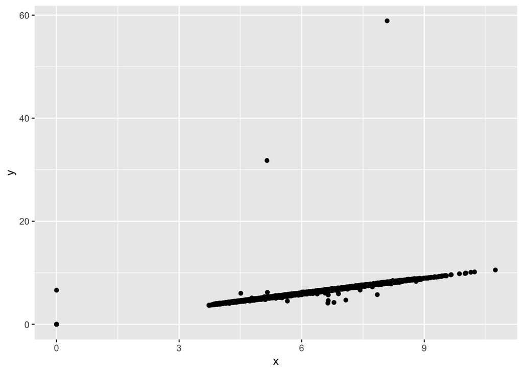

```r
qplot(x, y, data = diamonds)
```

**Now, let’s remove outliers!**

Let’s start figuring out what’s wrong with `x`.

```r
summary(diamonds$x)
```

```
##    Min. 1st Qu.  Median    Mean 3rd Qu.    Max.
##   0.000   4.710   5.700   5.731   6.540  10.740
```

Minimum of `x` is zero?! But `x` is supposed to be the lenght of the diamond, it can’t be `0`. Afterall, a diamond is a 3D object in real life!

How many zeros does `x` have?

```r
diamonds$x[diamonds$x == 0]
```

```
## [1] 0 0 0 0 0 0 0 0
```

Ok not that many, we can assign `NA`s to `0`s to let `qplot` know that these are missing values

```r
diamonds$x[diamonds$x == 0] <- NA
```

Now `0`s should be gone from the `Min.` and we should have `NA`s

```r
summary(diamonds$x)
```

```
##    Min. 1st Qu.  Median    Mean 3rd Qu.    Max.    NA's
##   3.730   4.710   5.700   5.732   6.540  10.740       8
```

Now let’s clean `y`!

```r
summary(diamonds$y)
```

```
##    Min. 1st Qu.  Median    Mean 3rd Qu.    Max.
##   0.000   4.720   5.710   5.735   6.540  58.900
```

Again, y shouldn’t be `0` because it’s the width. So we can assign `NA` to `0`s to let `qplot` know that these are missing values!

```r
diamonds$y[diamonds$y == 0] <- NA
```

Some of the `y` values are really large compared to `x`. Probably some of those are outliers as well.

```r
y_big <- diamonds$y > 20
diamonds$y[y_big] <- NA
```

Now the outliers are assigned as NA!

```r
summary(diamonds$y)
```

```
##    Min. 1st Qu.  Median    Mean 3rd Qu.    Max.    NA's
##   3.680   4.720   5.710   5.734   6.540  10.540       9
```

Let’s look at the plot once more with *relatively clean data*

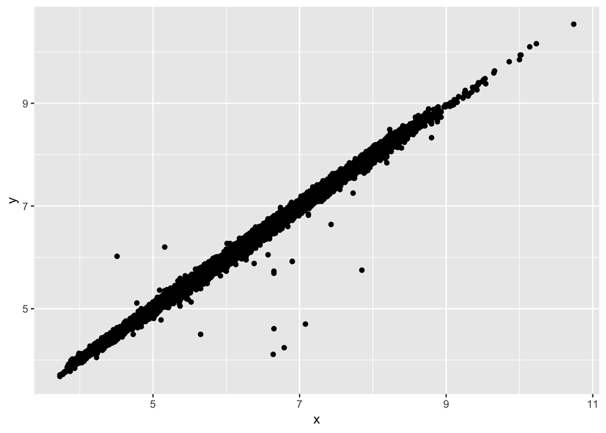

```r
qplot(x, y, data = diamonds)
```

Clever `qplot` removed the missing values from our plot!